# Support Vector Machine

Dr. Cong Zhang

*University of Baltimore

*This document mainly refers to the "Hands-on Machine Learning" chapter 5.*

A Support Vector Machine (SVM) is a powerful Machine Learning model, capable of performing linear or nonlinear classification, and regression. It is one of the most popular models in Machine Learning, and any one interested in Machine Learning should have it in their toolbox. In this document, we will learn how to implement SVM in Python.

## Linear SVM Classification

Linear SVM models are applicable when two classes are clearly linearly separable. The implementation of SVM is similar to the processes of implementing other ML models we learned before. The following cell loads the iris dataset (introduced previously), scales the features (neccessary for SVM), and then trains a linear SVM model to detect *Iris virginica* flowers:

```python
import warnings
warnings.simplefilter(action='ignore')
import numpy as np
from sklearn import datasets
from sklearn.pipeline import Pipeline
from sklearn.preprocessing import StandardScaler
from sklearn.svm import LinearSVC
from sklearn.model_selection import train_test_split

iris = datasets.load_iris()
X = iris["data"][:, (2, 3)] # petal length, petal width
y = (iris["target"] == 2).astype(np.float64) # Iris virginica
X_train, X_test, y_train, y_test = train_test_split(X, y, test_size=0.2)
svm_clf = Pipeline([
("scaler", StandardScaler()),
("linear_svc", LinearSVC(C=1, loss="hinge")),
])
svm_clf.fit(X_train, y_train)
```

```
Pipeline(steps=[('scaler', StandardScaler()),
                ('linear_svc', LinearSVC(C=1, loss='hinge'))])
```

```python
# Use the trained model to make predictions:
svm_clf.predict([[5.5, 1.7]])
# Note, unlike logistic regression classifiers,
# SVCs do not output probabilities for each class.
```

```
array([1.])
```

After getting the trained model, we can use cross-validation and test dataset to evaluate the model performance as usual:

```python
from sklearn.model_selection import cross_val_score
from sklearn.metrics import accuracy_score
svc_iris_scores = cross_val_score(svm_clf, X_train, y_train,
                            scoring="accuracy", cv=10)
print("The average accuracy score is:",svc_iris_scores.mean())

# Calculate the predictive accuracy
y_pred = svm_clf.predict(X_test)
pred_acc = accuracy_score(y_test, y_pred)
print("SVM predictive accuracy is {}%.".format(pred_acc*100))
```

```
The average accuracy score is: 0.9499999999999998
SVM predictive accuracy is 100.0%.
```

## Nonlinear SVM Classification

Although SVM can normally perform well on linearly separable data, it can also handle nonlinear data excellently using different kernels. Let's start with adding extra polynomial features in the model. Run the following cell to create and plot a double-moon data:

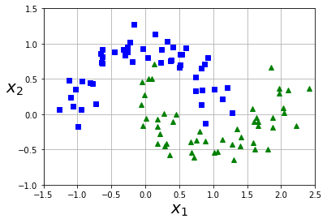

```python
import matplotlib.pyplot as plt
from sklearn.datasets import make_moons
X, y = make_moons(n_samples=100, noise=0.15, random_state=42)
def plot_dataset(X, y, axes):
    plt.plot(X[:, 0][y==0], X[:, 1][y==0], "bs")
    plt.plot(X[:, 0][y==1], X[:, 1][y==1], "g^")
    plt.axis(axes)
    plt.grid(True, which='both')
    plt.xlabel(r"$x_1$", fontsize=20)
    plt.ylabel(r"$x_2$", fontsize=20, rotation=0)
plot_dataset(X, y, [-1.5, 2.5, -1, 1.5])
plt.show()
```

The following cell creates third-degree polynomial features and integrates this process into a pipeline for a SVC on the double-moon data we just created:

```python
from sklearn.pipeline import Pipeline
from sklearn.preprocessing import PolynomialFeatures
polynomial_svm_clf = Pipeline([
# Third-degree polynomial features
("poly_features", PolynomialFeatures(degree=3)),
("scaler", StandardScaler()),
("svm_clf", LinearSVC(C=10, loss="hinge"))
])
polynomial_svm_clf.fit(X, y)
# Cross Validation
svc_moons_scores = cross_val_score(polynomial_svm_clf, X, y,
                            scoring="accuracy", cv=10)
print("The average accuracy score is:",svc_moons_scores.mean())
```

```
The average accuracy score is: 0.95
```

Run the following cell to visualize the decision boundary for our trained model:

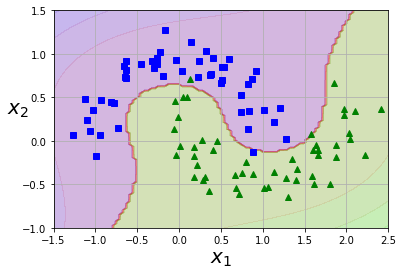

```python
def plot_predictions(clf, axes):
    x0s = np.linspace(axes[0], axes[1], 100)
    x1s = np.linspace(axes[2], axes[3], 100)
    x0, x1 = np.meshgrid(x0s, x1s)
    X = np.c_[x0.ravel(), x1.ravel()]
    y_pred = clf.predict(X).reshape(x0.shape)
    y_decision = clf.decision_function(X).reshape(x0.shape)
    plt.contourf(x0, x1, y_pred, cmap=plt.cm.brg, alpha=0.2)
    plt.contourf(x0, x1, y_decision, cmap=plt.cm.brg, alpha=0.1)

plot_predictions(polynomial_svm_clf, [-1.5, 2.5, -1, 1.5])
plot_dataset(X, y, [-1.5, 2.5, -1, 1.5])

plt.show()
```

### Polynomial Kernel

As we learned from the slides, for SVM, we can implement the polynomial transformation without really adding extra polynomial features in model using so-call *kernel trick*. The kernel for polynomial transformation is called the *polynomial kernel*. This trick is implemented by the SVC class. Let’s test it on the moons dataset:

```python
from sklearn.svm import SVC
poly_kernel_svm_clf = Pipeline([
        ("scaler", StandardScaler()),
    #Set the kernel to be poly and degree to 3.
        ("svm_clf", SVC(kernel="poly", degree=3, coef0=1, C=5))
    ])
poly_kernel_svm_clf.fit(X, y)
svc_poly_scores = cross_val_score(poly_kernel_svm_clf, X, y,
                            scoring="accuracy", cv=10)
print("The average accuracy score is:",svc_poly_scores.mean())
```

```
The average accuracy score is: 0.96
```